# Projekt modele liniowe i mieszane

Zadanie VI

Aleksandra Dąbrowska, Jan Dmitruk, Magda Młynarczyk

30 maja 2017

```r
library(dplyr)
library(ggplot2)
library(MASS)
library(knitr)
library(agricolae)
library(broom)
```

# 1 Przedstawienie problemu

W fazie 6 przeprowadzimy dodatkowe transformacje zmiennych objaśnianych i objaśniających naszego dotychczasowego modelu. Opiszemy też zmiany przeprowadzone już we wcześniejszych fazach projektu.

# 2 Podsumowanie

Rozpatrzyliśmy następujące transformacje zmiennej objaśnianej:

- Transformacja Boxa-Coxa 4.2
- Transformacja logarytmiczna oraz transformacja logarytmiczna z przesunięciem 4.3

Opisaliśmy także wykonane przez nas w poprzednich fazach przekształcenia zmiennych objaśniających:

- `zadanie` - informacja na temat numeru zadania 3.1
- `stat_m`, `stat_o` - informacja na temat statusu socjoekonomicznego matki i ojca, odpowiednio 3.2
- `gr_zawod_m`, `gr_zawod_o` - informacja na temat grupy zawodowej w obrębie której pracuje matka i ojciec 3.3
- `wyk_m`, `wyk_o` - informacja na temat wykształcenia rodziców. 3.4

Dzięki tym zmianom, zarówno dane jak i model stały się bardziej przejrzyste, a dzięki transformacjom danych model liniowy jest lepiej dopasowany.

# 3 Transformacje zmiennych objaśniających

Opiszemy najpierw transformacje, które przeprowadziliśmy w poprzednich fazach.

## 3.1 Wydobycie informacji o numerze zadania

W pierwotnych danych (`dane_matematyka`) dysponowaliśmy jedynie zmienną `kod_zadania`, zawierającą w sobie informacje zarówno o numerze zadania jak i o podpunkcie. Modelując czas całego zadania potrzebna nam była informacja o numerze zadania.

```r
dane_matematyka$zadanie <- substr(dane_matematyka$item_short,2,4)
```

## 3.2 Faktoryzacja statusu socjoekonomicznego

Jedną z rozważanych przez nas zmiennych, był status socjoekonomiczny matki i ojca danego ucznia. Zmienna ta przyjmowała wartości z przedziału [0,100]. Postanowiliśmy pogrupować je na pięć kategorii za pomocą funkcji `cut2`{Hmisc}

```r
library(Hmisc)
dane_kwestionariusze$stat_m <- cut2(dane_kwestionariusze$stat_m,c(20,40,60,80))
dane_kwestionariusze$stat_o <- cut2(dane_kwestionariusze$stat_o,c(20,40,60,80))
```

## 3.3 Przydzielenie grup zawodowych

```r
#wczytujemy kody poszczególnych zawodów.
kody_zawody <- readxl::read_excel("index08-draft.xlsx")
kody_zawody <- kody_zawody[,c(1,3)]

#wczytujemy kody grup zawodow
grupy_zawodow <- read.csv("occupations_groups.csv", sep=";",h=T)

#z danych z kwestionariusza wyciagniemy informacje o grupie zawodow w ktorych sa rodzice
dane_kwestionariusze$gr_zawod_m <- substr(dane_kwestionariusze$zawod_m,1,2)
dane_kwestionariusze$gr_zawod_o <- substr(dane_kwestionariusze$zawod_o,1,2)

#teraz do danych dodajemy nazwe grupy
colnames(grupy_zawodow)[1] <- "gr_zawod_m"
grupy_zawodow$gr_zawod_m <- as.character(grupy_zawodow$gr_zawod_m)
grupy_zawodow[1,1] <- "01"
grupy_zawodow[2,1] <- "02"
grupy_zawodow[3,1] <- "03"

dane_kwestionariusze2 <- left_join(dane_kwestionariusze,grupy_zawodow, by="gr_zawod_m")
dane_kwestionariusze2$Name <- droplevels(dane_kwestionariusze2$Name)
colnames(dane_kwestionariusze2)[12] <- "n_zawod_m"

colnames(grupy_zawodow)[1] <- "gr_zawod_o"
dane_kwestionariusze2 <- left_join(dane_kwestionariusze2,grupy_zawodow, by="gr_zawod_o")
dane_kwestionariusze2$Name <- droplevels(dane_kwestionariusze2$Name)

colnames(dane_kwestionariusze2)[13] <- "n_zawod_o"
```

## 3.4 Przekształcone dane

Po powyższych przekształceniach zmienne niezależne prezentują się następująco:

```
##     id_ucznia   wyk_m   wyk_o  stat_m  stat_o gr_zawod_m gr_zawod_o
## 1    24604114      5B      5B [20,40) [20,40)         53         81
## 26   24602255   5A, 6   5A, 6 [60,80) [20,40)         25         52
## 49   24603584  3A,  4  3A,  4 [20,40) [20,40)         52         71
## 63   24602174      5B   5A, 6 [40,60) [40,60)         32         31
## 86   24601434   5A, 6       2 [40,60) [11,20)         14         83
## 111  24602676   5A, 6      5B [40,60) [60,80)         33         33
```

## 3.5 Wykształcenie rodziców

Wśród zmiennych znajdujących się w danych z kwestionariusza znajdują się także te mówiące o wykształceniu rodziców danego dziecka. Jest to zmienna posiadajca siedem poziomów:

```r
table(dane_nowe$wyk_m)
```

```
##
##       1       2  3A,  4   3B, C   5A, 6      5B    None
##    3560   18989   39199   13438   53593   19253    1716
```

Chcemy zmiejszyć listę poziomów powyższych zmiennych wykonując testy post-hoc. Najpierw budujemy model oparty na wybranych wcześniej zmiennych.

```r
Model <- lm(czas_zadania~zadanie*pozycja_zadania+id_kwestionariusza+mies_ur+id_kraju*plec+wyk_m*wyk_o+gr_zawod_m+gr_zawod_o+stat_m+stat_o, data = dane_nowe)
```

Korzystając z funkcji `LSD.test{agricolae}` wykonujemy testowanie post-hoc.

```r
post_hoc_o <- LSD.test(Model, "wyk_o")
kable(post_hoc_o$groups)
```

| trt | means | M |
| --- | --- | --- |
| 3A, 4 | 205.2148 | a |
| 5A, 6 | 204.4951 | a |
| 5B | 199.6667 | b |
| 3B, C | 199.0128 | bc |
| 2 | 198.2142 | bc |
| 1 | 196.7228 | bc |
| None | 194.7329 | c |

```r
post_hoc_m <- LSD.test(Model, "wyk_m")
kable(post_hoc_m$groups)
```

| trt | means | M |
| --- | --- | --- |
| None | 205.3229 | a |
| 5A, 6 | 205.2277 | a |
| 3A, 4 | 202.3542 | a |
| 1 | 201.1026 | ab |
| 5B | 200.1152 | b |
| 3B, C | 200.1030 | b |
| 2 | 197.7555 | b |

Możemy zmienną `wyk_o` podzielić na trzy grupy:

- pierwsza zawierająca poziomy `3A,4`,`5A,6`
- druga zawierająca poziomy `5B`, `3B,C`, `2`
- trzecia zawierająca poziomy `1` i `None`,

a zmienną `wyk_m` na dwie grupy:

- poziomy `None`, `5A,6`, `3A,4`
- poziomy `1`, `5B`, `3B,C`, `2`.

```r
dane_nowe$wyk_m_ch <- as.character(dane_nowe$wyk_m)
dane_nowe$wyk_o_ch <- as.character(dane_nowe$wyk_o)
dane_nowe <-dane_nowe %>% mutate(wyk_o_lsd = case_when(.$wyk_o %in% c(" 3A,   4"," 5A,  6") ~ "a",
                                            .$wyk_o %in% c(" 5B"," 3B,  C"," 2") ~ "b",
                                            .$wyk_o %in% c(" 1","None") ~"c"
                                            ),
                                wyk_m_lsd = case_when(.$wyk_m %in% c("None"," 5A,  6"," 3A,  4") ~ "a",
                                            .$wyk_m %in% c(" 1"," 5B"," 3B,  C"," 2") ~ "b"))
```

```r
model_gr <- lm(czas_zadania~zadanie*pozycja_zadania+id_kwestionariusza+mies_ur+id_kraju*plec+wyk_m_lsd*wyk_o_lsd+gr_zawod_m+gr_zawod_o+stat_m+stat_o, data = dane_nowe)
```

```r
AIC(Model)
```

```
## [1] 1802796
```

```r
AIC(model_gr)
```

```
## [1] 406055.7
```

Jak widzimy model z pogrupowanymi zmiennymi ma mniejsze AIC i to ten model będziemy rozważać w kolejnych analizach.

# 4 Transformacje czasu

## 4.1 Agregowanie czasu zadania ze względu na podpunkt

W pierwszej fazie naszego projektu zdedcydowaliśmy modelować czas rozwiązywania całego zadania przez ucznia, pomimo posiadania informacji na temat czasu rozwiązywania poszczególnych podpunktów. Aby było to możliwe, ze zmiennej `kod_zadania` wyciągnęliśmy numer podpunktu danego zadania 3.1, a następnie posumowaliśmy czasy ze wszystkich podpunktów danego zadania (pełny kod: https://github.com/pbiecek/LinearModels/blob/master/MIMUW_2017/Projekty/A.Dabrowska-%20J.Dmitruk-%20M.Mlynaryczyk/Raport_zadanie_1.Rmd).

```r
dane6 <- dane6 %>% group_by(CNTSTUID,zadanie) %>% summarize(sum(czas))
```

Ze względu na nieliniowość naszego modelu rozpatrywaliśmy już w poprzednich fazach różne transformacje czasu. W fazie 4 porównywaliśmy transformacje $\log(t)$ z transformacjami typu $t^{\alpha}$. Zdecydowaliśmy, że modelowanie logarytmu czasu jest lepsze. Przeprowadźmy jeszcze raz to rozumowanie, uwzględniając interakcje rozważane w poprzedniej fazie.

## 4.2 Transformacje

### 4.2.1 Transformacje Boxa-Coxa

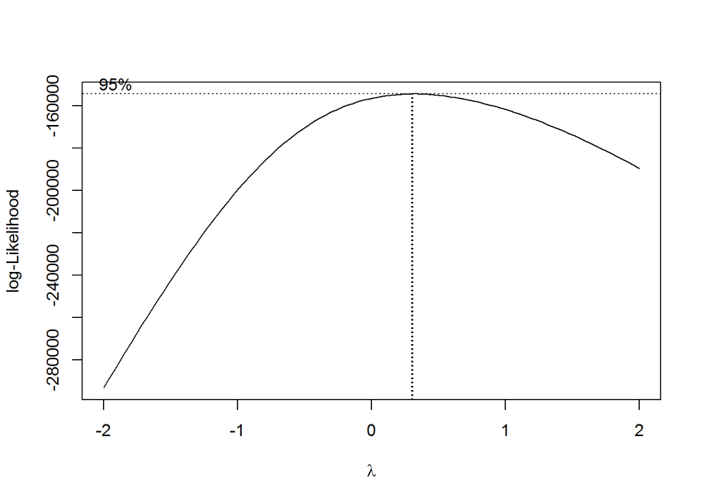

```r
Model <- lm(czas_zadania~zadanie*pozycja_zadania+id_kwestionariusza+mies_ur+id_kraju*plec+wyk_m_lsd*wyk_o_lsd+gr_zawod_m+gr_zawod_o+stat_m+stat_o, data = dane_nowe)

wsp <- boxcox(Model)
```

```r
wsp <- wsp$x[which.max(wsp$y)]

BoxModel <- lm(I(((czas_zadania)^wsp-1)/wsp)~zadanie*pozycja_zadania+id_kwestionariusza+mies_ur+id_kraju*plec+wyk_m_lsd*wyk_o_lsd+gr_zawod_m+gr_zawod_o+stat_m+stat_o, data = dane_nowe)

BoxModel2 <- lm(I((czas_zadania)^wsp)~zadanie*pozycja_zadania+id_kwestionariusza+mies_ur+id_kraju*plec+wyk_m_lsd*wyk_o_lsd+gr_zawod_m+gr_zawod_o+stat_m+stat_o, data = dane_nowe)


AIC(BoxModel)
```

```
## [1] 155939.8
```

```r
AIC(BoxModel2)
```

```
## [1] 75440.73
```

### 4.2.2 Transformacje logrytmiczne

Na początku wykonamy zwykła transformację logarytmiczną czasu. Następnie rozważymy także wybór parametru przesunięcia w transformacji logarytmicznej przy pomocy funkcji `logtrans`{MASS}

```r
LogModel <- lm(log(czas_zadania)~zadanie*pozycja_zadania+id_kwestionariusza+mies_ur+id_kraju*plec+wyk_m_lsd*wyk_o_lsd+gr_zawod_m+gr_zawod_o+stat_m+stat_o, data = dane_nowe)

beta <- logtrans(Model, alpha = seq(0.5, 80, 0.5))
```

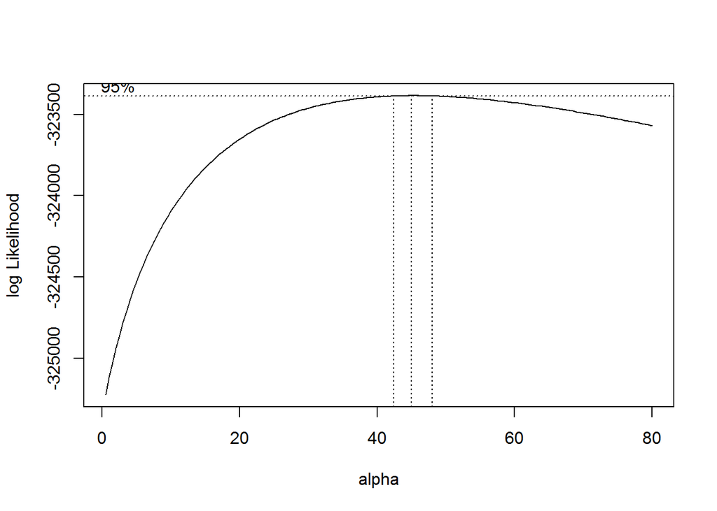

```r
beta <- beta$x[which.max(beta$y)]

LogTransModel <- lm(log(czas_zadania + beta)~zadanie*pozycja_zadania+id_kwestionariusza+mies_ur+id_kraju*plec+wyk_m_lsd*wyk_o_lsd+gr_zawod_m+gr_zawod_o+stat_m+stat_o, data = dane_nowe)
```

### 4.2.3 Wybór optymalnej transformacji

Porównamy powyższe modele między sobą za pomocą parametru R squared.

```r
rsq <- c("Model", "LogModel", "BoxModel", "LogTransModel")
rsq <- cbind(rsq, c(summary(Model)$r.squared, summary(LogModel)$r.squared,summary(BoxModel2)$r.squared, summary(LogTransModel)$r.squared))

colnames(rsq) <- c("nazwa modelu", "R squared")

kable(rsq, caption="Wartości R-squared dla rozważanych modeli")
```

Wartosci R-squared dla rozwazanych modeli

| nazwa modelu | R squared |
| --- | --- |
| Model | 0.504069397736033 |
| LogModel | 0.508021064364659 |
| BoxModel | 0.530767479340306 |
| LogTransModel | 0.53789812826835 |

```r
AIC <- c("Model", "LogModel", "BoxModel", "LogTransModel")
AIC <- cbind(AIC, c(AIC(Model), AIC(LogModel),AIC(BoxModel2), AIC(LogTransModel)))

colnames(AIC) <- c("nazwa modelu", "AIC")

kable(AIC, caption = "Wartości AIC dla rozważanych modeli")
```

Wartosci AIC dla rozwazanych modeli

| nazwa modelu | AIC |
| --- | --- |
| Model | 406055.697059297 |
| LogModel | 57628.5347688082 |
| BoxModel | 75440.7344714133 |
| LogTransModel | 31985.7601887903 |

Okazuje się, że najniższą wartość kryterium Akaike otrzymujemy przy transformacji logarytmicznej z przesunięciem.

## 4.3 Wizualizacja reszt

Dla przedstawionych powyżej przekształceń zmiennej objaśnianej, sprawdzimy, dzięki któremu, rozkład reszt jest najbliższy normalnemu.

Dla modelu bez transformacji.

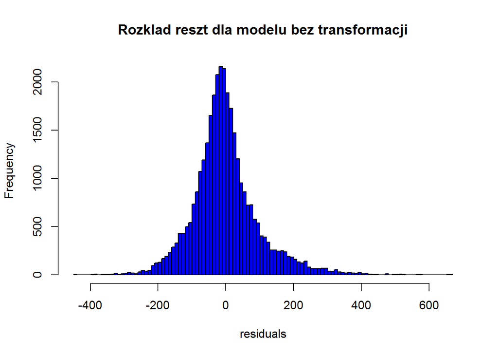

```r
dane_model <-augment(Model)
hist(dane_model$.resid, col="blue", xlab="residuals", main="Rozkład reszt dla modelu bez transformacji", breaks=100)
```

```r
skewness(dane_model$.resid)
```

```
## [1] 0.8479173
```

```r
kurtosis(dane_model$.resid)
```

```
## [1] 2.947079
```

Dla modelu z transformacją z rodziny Boxa-Coxa.

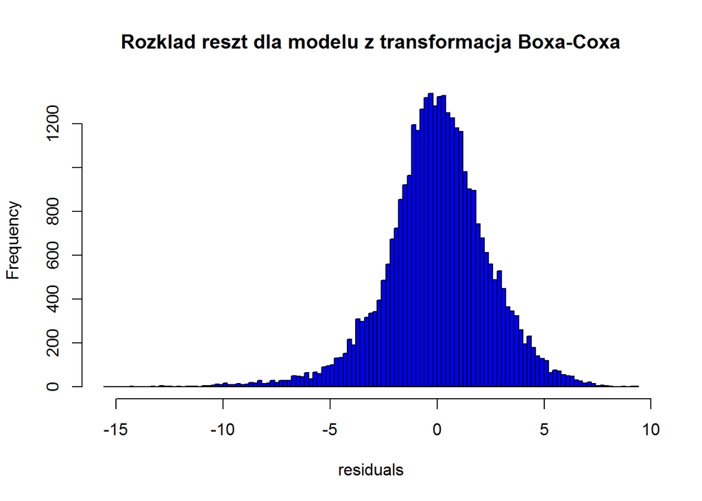

```r
dane_model <-augment(BoxModel)
hist(dane_model$.resid, col="blue", xlab="residuals", main="Rozkład reszt dla modelu z transformacją Boxa-Coxa", breaks=100)
```

```r
skewness(dane_model$.resid)
```

```
## [1] -0.4552616
```

```r
kurtosis(dane_model$.resid)
```

```
## [1] 1.856407
```

Dla modelu z logarytmem.

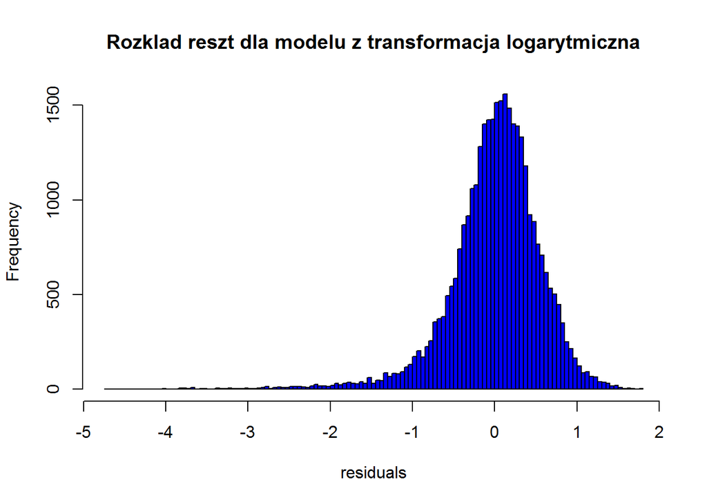

```r
dane_model<-augment(LogModel)
hist(dane_model$.resid, col="blue", xlab="residuals", main="Rozkład reszt dla modelu z transformacja logarytmiczna", breaks=100)
```

```r
skewness(dane_model$.resid)
```

```
## [1] -1.371437
```

```r
kurtosis(dane_model$.resid)
```

```
## [1] 5.620848
```

Dla modelu z przesunięciem logarytmicznym równym $\beta = 45$.

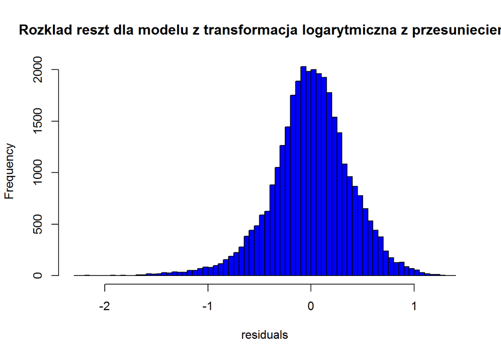

```r
dane_model <-augment(LogTransModel)
hist(dane_model$.resid, col="blue", xlab="residuals", main="Rozkład reszt dla modelu z transformacja logarytmiczna z przesunieciem", breaks=100)
```

```r
skewness(dane_model$.resid)
```

```
## [1] -0.4496276
```

```r
kurtosis(dane_model$.resid)
```

```
## [1] 1.443931
```

Widzimy, że najlepiej rozkład reszt poprawia nam transformacja logarytmiczna z przesunięciem. Ze wszystkich przedstawionych jest najbardziej zbliżony do normalnego (kurtoza i skośność najbliżej 0).